# Final project R

Ahmed Tarek Sayed

February 12, 2018

## importing the datasets

```r
tmdb_movies_metadata <- read_csv("E:/Academic/ITI/R/Evaluation Project/R for Data Science course evaluation/tmdb_movies_metadata.csv")
tmdb_cast_crew <- read_csv("E:/Academic/ITI/R/Evaluation Project/R for Data Science course evaluation/tmdb_cast_crew.csv")
```

### ï· Is there a relationship between movie the number of budget and the movie rating?

```r
tmdb_movies_metadata %>% select(budget, vote_average)%>% summary()
```

```
##      budget           vote_average
##  Min.   :        0   Min.   : 0.000
##  1st Qu.:   800000   1st Qu.: 5.600
##  Median : 15000000   Median : 6.200
##  Mean   : 29092674   Mean   : 6.093
##  3rd Qu.: 40000000   3rd Qu.: 6.800
##  Max.   :380000000   Max.   :10.000
```

the mean is far away from median indicating the variable is right skewed, indicating the presence of extremes or ouytliers in the budget variable however the voting is balanced.

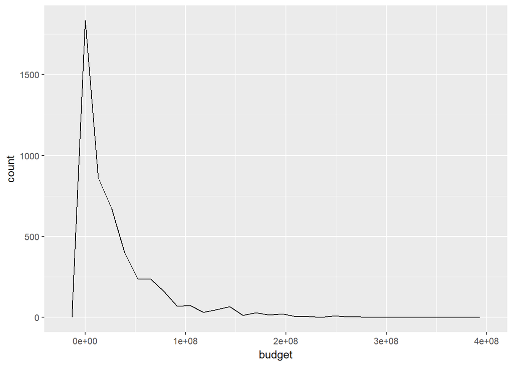

```r
tmdb_movies_metadata %>% ggplot() + geom_freqpoly(mapping = aes(x=budget ))
```

there is clearly very large number of movies with budget = 0!! Iwill devide the budget into 20 equal parts to try to see if the 0 budget movies are an entry (null) or not.

```r
tmdb_movies_metadata %>% mutate(percentile = ntile(budget,20)) %>% select(percentile, budget,vote_average,vote_count) %>% group_by(percentile) %>% summarise(n(), mean(budget),min(budget),median(budget), max(budget), mean(vote_average), mean(vote_count) )
```

```
## # A tibble: 20 x 8
##    percentile `n()` `mean(budget)` `min(budget)` `median(budget)`
##         <int> <int>          <dbl>         <dbl>            <dbl>
##  1          1   240              0             0                0
##  2          2   240              0             0                0
##  3          3   240              0             0                0
##  4          4   239              0             0                0
##  5          5   240         191379             0            50000
##  6          6   240        1587942        800000          1500000
##  7          7   240        3718498       2600000          3650000
##  8          8   239        6161687       5000000          6000000
##  9          9   240        9249936       7700000          9500000
## 10         10   240       12592065      11000000         12352762
## 11         11   240       16001828      15000000         16000000
## 12         12   239       19833012      18000000         20000000
## 13         13   240       24528812      22000000         25000000
## 14         14   240       29473271      27000000         30000000
## 15         15   240       36060902      32000000         35000000
## 16         16   239       43845095      40000000         44000000
## 17         17   240       54867083      50000000         55000000
## 18         18   240       69146819      60000000         70000000
## 19         19   240       92140464      80000000         90000000
## 20         20   239      162817992     115000000        150000000
## # ... with 3 more variables: `max(budget)` <dbl>,
## #   `mean(vote_average)` <dbl>, `mean(vote_count)` <dbl>
```

I can see normal equal average voting rate in all 20 parts regardless of the 0 budget, so I will deal with them as an entry error.

all 20 parts are almost normally dist with mean = media except in the 5th which is the break point between the 0 budget(entery error) and the non 0, so i will try to get the best number that separate the real data from the entery error

```r
tmdb_movies_metadata %>%filter(budget < 100000) %>% mutate(percentile = ntile(budget,30)) %>% select(percentile, budget,vote_average,vote_count) %>% group_by(percentile) %>% summarise(n(), mean(budget),min(budget),median(budget), max(budget) )
```

```
## # A tibble: 30 x 6
##    percentile `n()` `mean(budget)` `min(budget)` `median(budget)`
##         <int> <int>          <dbl>         <dbl>            <dbl>
##  1          1    37              0             0                0
##  2          2    36              0             0                0
##  3          3    36              0             0                0
##  4          4    37              0             0                0
##  5          5    36              0             0                0
##  6          6    36              0             0                0
##  7          7    37              0             0                0
##  8          8    36              0             0                0
##  9          9    36              0             0                0
## 10         10    36              0             0                0
## # ... with 20 more rows, and 1 more variable: `max(budget)` <dbl>
```

```r
tmdb_movies_metadata %>%filter(budget %in% (1:50000)) %>% select(title, release_date, budget, vote_average, vote_count, popularity, runtime) %>%  arrange(budget)
```

```
## # A tibble: 48 x 7
##    title    release_date budget vote_average vote_count popularity runtime
##    <chr>    <date>        <int>        <dbl>      <int>      <dbl>   <int>
##  1 Modern ~ 1936-02-05        1         8.10        856   28.3          87
##  2 Me You ~ 2015-07-07        1        10.0           2    0.0941       90
##  3 Fetchin~ 2005-10-01        1         6.80          6    0.0779       87
##  4 Inciden~ 2004-12-17        1         5.90         18    1.45         94
##  5 The Alg~ 2015-08-07        1         0             0    0.0254       99
##  6 Slam     1998-10-07        1         6.70          7    0.292       100
##  7 Fear Cl~ 2014-10-31        1         4.00         42    1.86         95
##  8 To Be F~ 2015-12-12        2         0             0    0.0506       NA
##  9 Four Si~ 2009-01-15        3         0             0    0.00826     100
## 10 A Farew~ 1932-12-08        4         6.20         28    1.20         89
## # ... with 38 more rows
```

Can old movies budget be that small? I have checked the IMDP data base to see if even the old movies <1940 budget can make sense with very low numbers but my search revealed error with these entery examples of errors compared to imdb:- http://www.imdb.com/title/tt0022879/ dataset:4 imdb:800K http://www.imdb.com/title/tt1714210/ dataset:8000 imdb:120K

Idecided to take >8000 as the limit of real non outliers data

```r
filtered_movies <- tmdb_movies_metadata %>% filter(budget >8000)
```

Trying to visualise the relation bettween voting average and budget.

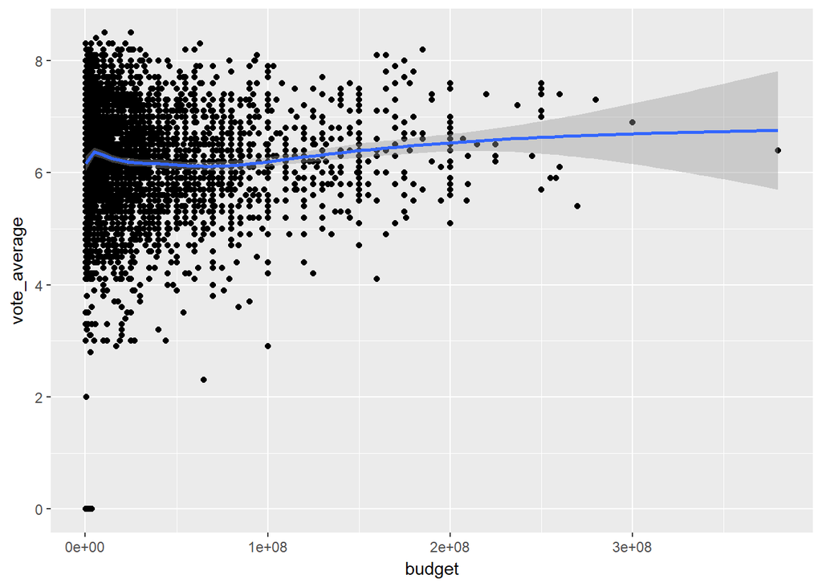

```r
filtered_movies %>% ggplot(aes(x=budget, y=vote_average)) + geom_point() + geom_smooth()
```

It seems that there is no correlation. My interpertation : we have 2 problems :- 1- we cannot compare budget from diffrent years to each other 2- voting rate can be really missleading specially with with low voting count

I will extract the year of release from date

```r
filtered_movies <- filtered_movies %>% mutate(release_year = format(release_date,"%Y"))
```

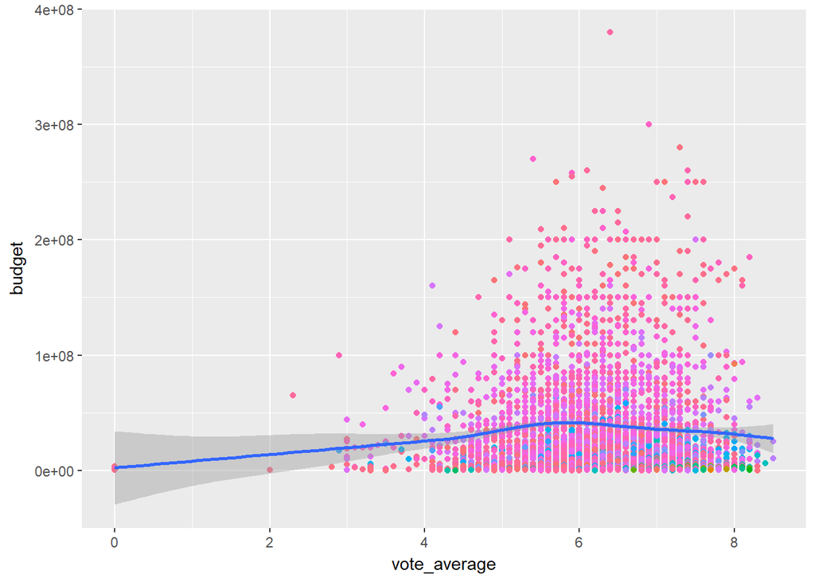

```r
filtered_movies %>% ggplot(aes(x=vote_average, y=budget)) + geom_point(aes(color = release_year),show.legend = F) + geom_smooth()
```

I have downloaded cpi dataset from https://datahub.io/core/cpi-us#data and inner joined it to movie dataset to be able to adjust budget per year

```r
cpiai_csv <- read_csv("E:/Academic/ITI/R/Evaluation Project/R for Data Science course evaluation/cpiai_csv.csv",
    col_types = cols(Date = col_date(format = "%d/%m/%Y")))

cpi <- cpiai_csv %>% transmute(release_year = format(Date,"%Y"), cpi= Index)

cpi <- cpi %>%  group_by(release_year) %>% summarise( cpi = mean(cpi, na.rm = T))

indexed_movies <- cpi %>% select(release_year, cpi) %>% right_join(filtered_movies, by = "release_year")
```

I have got the mean cpi for the year and then right joind the cpi to the movie dataset with the year

```r
indexed_movies <- indexed_movies %>% mutate( indexed_budget = budget/cpi)
```

I have created a new variable called the indexed_budget revealing the budget in relation to yearly index

Now lets examine the relation between the total_votes(count*average) againist the indexed budget

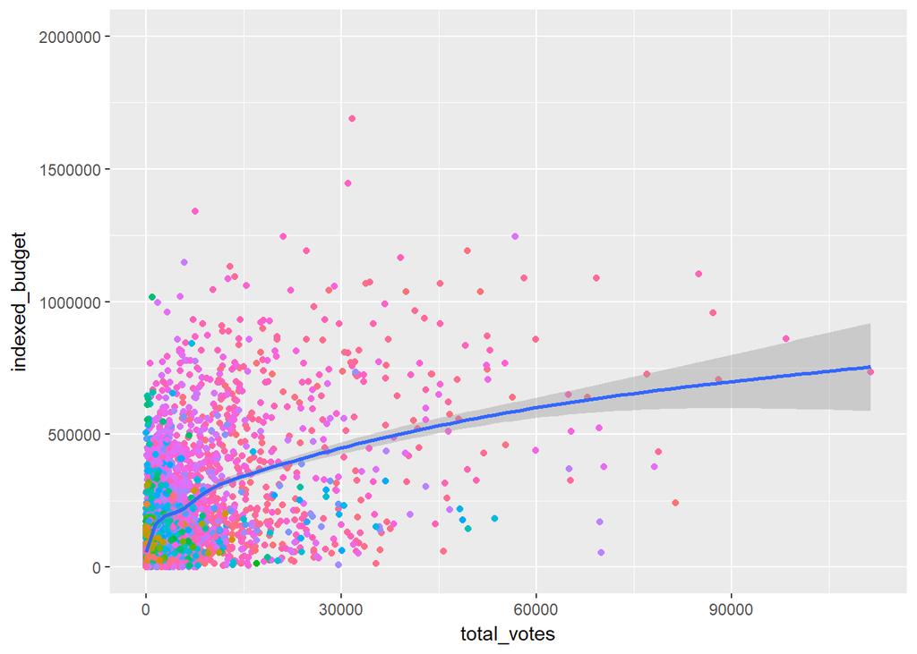

```r
indexed_movies %>% mutate(total_votes = vote_count*vote_average) %>%  ggplot(aes(x=total_votes, y=indexed_budget)) + geom_point(mapping = aes(color = release_year), show.legend = F) + geom_smooth() + ylim(NA,2000000)
```

there is a moderate correlation between the two but from the colors we can see that there is a clear groupping by the year. the voting count is increasing throw the years making this correlation noised by the effect of count per time

```r
indexed_movies %>% filter(indexed_budget > 4000000)
```

```
## # A tibble: 1 x 17
##   release_year   cpi movie_id title   original_langua~ release_date budget
##   <chr>        <dbl>    <int> <chr>   <chr>            <date>        <int>
## 1 1927          17.4       19 Metrop~ de               1927-01-10   9.26e7
## # ... with 10 more variables: revenue <dbl>, runtime <int>,
## #   vote_average <dbl>, vote_count <int>, popularity <dbl>, genres <chr>,
## #   keywords <chr>, production_companies <chr>,
## #   production_countries <chr>, indexed_budget <dbl>
```

after checking the movie at imdb http://www.imdb.com/title/tt0017136/ dataset:92m imdb:6m (clearly an error)

### What are the genres that have the highest average rating?

First of all i need to know the max number of genres per movie

```r
indexed_movies %>% transmute(count_gen = str_count(genres, fixed("|")) +1) %>% summarise(max(count_gen, na.rm = T))
```

```
## # A tibble: 1 x 1
##   `max(count_gen, na.rm = T)`
##                         <dbl>
## 1                        7.00
```

Then I am going to separate these words

```r
spr_gen_movies <- indexed_movies %>% separate(genres, into = paste("gen", 1:7, sep = "_"))
```

Now I amgoing to gather them and filter all the nulls to make a group function

```r
gen_movies <- spr_gen_movies %>%  gather(num_range("gen_", 1:7), key = "gen_no", value = "gen") %>% filter(!is.na(gen))
```

Now lets play :D

```r
gen_movies <- gen_movies %>% mutate(total_votes = vote_count*vote_average)
gen_movies %>% group_by(gen) %>% summarise(avg_rate = mean(vote_average), avg_total_votes = mean(total_votes)) %>% arrange(desc(avg_rate))
```

```
## # A tibble: 22 x 3
##    gen         avg_rate avg_total_votes
##    <chr>          <dbl>           <dbl>
##  1 War             6.77          5996
##  2 History         6.76          4054
##  3 Foreign         6.70            76.1
##  4 Documentary     6.66           765
##  5 Western         6.56          5153
##  6 Music           6.53          2586
##  7 Drama           6.51          4848
##  8 Animation       6.42          9738
##  9 Crime           6.38          6016
## 10 Mystery         6.29          6254
## # ... with 12 more rows
```

it looks like war then history then forign movies is the one with highest avg_rate but why do I feel like it is not the truth, You dont see alot of fans of war or forign movies :D but lets see the total_votes(count*average) as it is a more accurate indicator.

```r
gen_movies <- gen_movies %>% mutate(total_votes = vote_count*vote_average)
gen_movies %>% group_by(gen) %>% summarise(avg_rate = mean(vote_average), avg_total_votes = mean(total_votes)) %>% arrange(desc(avg_total_votes))
```

```
## # A tibble: 22 x 3
##    gen       avg_rate avg_total_votes
##    <chr>        <dbl>           <dbl>
##  1 Fiction       6.09           10747
##  2 Science       6.09           10727
##  3 Adventure     6.18           10523
##  4 Fantasy       6.13            9817
##  5 Animation     6.42            9738
##  6 Action        6.07            8548
##  7 Family        6.12            7509
##  8 Mystery       6.29            6254
##  9 Thriller      6.13            6047
## 10 Crime         6.38            6016
## # ... with 12 more rows
```

Now the results are more logical, the top 4 genres are fiction, scince, adventure then fantasy looks like the next part of the avenger series going to be a hit :D

### What are the plot keywords that have the highest average rating?

first I need to count the maximum number of keywords in single row

```r
indexed_movies %>% transmute(count_key = str_count(keywords, fixed("|")) +1) %>% summarise(max(count_key, na.rm = T))
```

```
## # A tibble: 1 x 1
##   `max(count_key, na.rm = T)`
##                         <dbl>
## 1                        97.0
```

Now I am going separate the column into 97 column(max number of keywords per row)

```r
spr_key_movies <- indexed_movies %>% separate(keywords, into = paste("key", 1:97, sep = "_"))
```

Then I am going to gather al columns in on column by repeating records and removing the nulls to be able to make group function

```r
key_movies <- spr_key_movies %>%  gather(num_range("key_", 1:97), key = "key_no", value = "key") %>% filter(!is.na(key))
```

I have made groupping by the keywords and summarised the mean of the avg rating and also my total_vote(calculated)

```r
key_movies <- key_movies %>% mutate(total_votes = vote_count*vote_average)

key_movies %>% group_by(key) %>% summarise(avg_rate = mean(vote_average), avg_total_votes = mean(total_votes)) %>% arrange(desc(avg_rate))
```

```
## # A tibble: 6,797 x 3
##    key          avg_rate avg_total_votes
##    <chr>           <dbl>           <dbl>
##  1 conservatory     8.30           35308
##  2 heirloom         8.30           69952
##  3 kamikaze         8.30           69952
##  4 massage          8.30           69952
##  5 montage          8.30           35308
##  6 pulp             8.30           69952
##  7 punches          8.30           27705
##  8 yokai            8.30           31872
##  9 amputee          8.20           65001
## 10 basic            8.20           23936
## # ... with 6,787 more rows
```

```r
key_movies %>% group_by(key) %>% summarise(avg_rate = mean(vote_average), avg_total_votes = mean(total_votes)) %>% arrange(desc(avg_total_votes))
```

```
## # A tibble: 6,797 x 3
##    key          avg_rate avg_total_votes
##    <chr>           <dbl>           <dbl>
##  1 astrophysics     8.10           88023
##  2 relativity       8.10           88023
##  3 zero             8.10           88023
##  4 django           7.80           78772
##  5 heirloom         8.30           69952
##  6 kamikaze         8.30           69952
##  7 massage          8.30           69952
##  8 pulp             8.30           69952
##  9 peak             7.20           67874
## 10 glamour          6.90           65240
## # ... with 6,787 more rows
```

Using the vote_avg shows that conservatory, heirloom then kamikaze are the key words with the highst rate

## Who are the highly rated directors? Who are the highly rated actors?

In order to see the highly rated director I need to join the 2 tables of metadata and crew and why dont we also calculate the (vote_count * vote_average) to see which KPI is more accurate

```r
full_movies <- left_join(indexed_movies, tmdb_cast_crew, by = "movie_id")
full_movies <- full_movies %>% mutate(total_votes = vote_count*vote_average)
```

now lets see the director with the highest rating averrage

```r
full_movies %>% group_by(director) %>% summarise(sum_vote = sum(vote_average), sum_total = sum(total_votes)) %>%  arrange(desc(sum_vote))
```

```
## # A tibble: 1,716 x 3
##    director          sum_vote sum_total
##    <chr>                <dbl>     <dbl>
##  1 Steven Spielberg     188      431883
##  2 Martin Scorsese      131      252177
##  3 Clint Eastwood       130      139832
##  4 Woody Allen          108       62629
##  5 Ridley Scott         107      260575
##  6 Steven Soderbergh     94.9     95176
##  7 Tim Burton            94.2    194046
##  8 Oliver Stone          92.6     41602
##  9 Robert Zemeckis       89.9    247910
## 10 Renny Harlin          85.8     33770
## # ... with 1,706 more rows
```

```r
full_movies %>% group_by(director) %>% summarise(sum_vote = sum(vote_average), sum_total = sum(total_votes)) %>%  arrange(desc(sum_total))
```

```
## # A tibble: 1,716 x 3
##    director          sum_vote sum_total
##    <chr>                <dbl>     <dbl>
##  1 Christopher Nolan     62.4    497790
##  2 Steven Spielberg     188      431883
##  3 Quentin Tarantino     75.5    347310
##  4 Peter Jackson         66.0    345623
##  5 David Fincher         73.4    281190
##  6 Ridley Scott         107      260575
##  7 Martin Scorsese      131      252177
##  8 Robert Zemeckis       89.9    247910
##  9 James Cameron         51.3    242154
## 10 Tim Burton            94.2    194046
## # ... with 1,706 more rows
```

I have arranged the list both by sum of vote average (using the mean give very poor accuracy) and sum total_votes. The total votes KPI shows to be more accurate than vote averrage when compared to imdb(one can know which is better just by seeing Christopher Nolan at the top :D) Refrence : http://www.imdb.com/list/ls069174126/

1regarding the best actor:- I have gathered all the acttors in one value column ‘actor’ and removed any null columns

```r
actor_movie <- full_movies %>%
    gather(key = actor_no, value = actor, starts_with('actor'), na.rm = T)
```

now lets see using our KPIs

```r
actor_movie %>% group_by(actor) %>% summarise(sum_vote = sum(vote_average), sum_total = sum(total_votes)) %>%  arrange(desc(sum_vote))
```

```
## # A tibble: 4,236 x 3
##    actor             sum_vote sum_total
##    <chr>                <dbl>     <dbl>
##  1 Robert De Niro         284    254734
##  2 Matt Damon             233    396771
##  3 Bruce Willis           219    304883
##  4 Johnny Depp            205    425982
##  5 Brad Pitt              204    479034
##  6 Nicolas Cage           202    156382
##  7 Tom Hanks              192    467845
##  8 Morgan Freeman         189    295230
##  9 Denzel Washington      188    177652
## 10 Tom Cruise             185    329627
## # ... with 4,226 more rows
```

```r
actor_movie %>% group_by(actor) %>% summarise(mean_vote = mean(vote_average), sum_total = sum(total_votes)) %>%  arrange(desc(sum_total))
```

```
## # A tibble: 4,236 x 3
##    actor             mean_vote sum_total
##    <chr>                 <dbl>     <dbl>
##  1 Leonardo DiCaprio      7.24    566012
##  2 Robert Downey Jr.      6.73    485383
##  3 Brad Pitt              6.80    479034
##  4 Tom Hanks              7.10    467845
##  5 Johnny Depp            6.60    425982
##  6 Ian McKellen           7.08    418390
##  7 Christian Bale         6.86    399152
##  8 Matt Damon             6.65    396771
##  9 Will Smith             6.44    345296
## 10 Harrison Ford          6.61    336620
## # ... with 4,226 more rows
```

well now both give moderate reults now(I think it is up to ones taste now :D)

## Who are the most profitable directors? Who are the most profitable actors?

In order to know profit we need to calc it (profit = revenue - cost(budget)) then I am going to devide by the (consumer price index) to be able to compare diffrent times

```r
full_movies %>% mutate(profit = revenue - budget, indexed_profit = profit/cpi) %>% group_by(director) %>% summarise(sum_profit = sum(profit), sum_indexed_profit = sum(indexed_profit)) %>% arrange(desc(sum_profit))
```

```
## # A tibble: 1,716 x 3
##    director          sum_profit sum_indexed_profit
##    <chr>                  <dbl>              <dbl>
##  1 Steven Spielberg  7479893164           60042001
##  2 Peter Jackson     5205642820           25971508
##  3 James Cameron     5136669439           29360930
##  4 Michael Bay       4422524638           21853057
##  5 Christopher Nolan 3222483234           14724666
##  6 Chris Columbus    3098631503           19050669
##  7 George Lucas      2979336893           27323313
##  8 Robert Zemeckis   2600622002           17576840
##  9 Joss Whedon       2424831068           10452608
## 10 Francis Lawrence  2349457182           10300225
## # ... with 1,706 more rows
```

```r
full_movies %>% mutate(profit = revenue - budget, indexed_profit = profit/cpi) %>% group_by(director) %>% summarise(sum_profit = sum(profit), sum_indexed_profit = sum(indexed_profit)) %>% arrange(desc(sum_indexed_profit))
```

```
## # A tibble: 1,716 x 3
##    director          sum_profit sum_indexed_profit
##    <chr>                  <dbl>              <dbl>
##  1 Steven Spielberg  7479893164           60042001
##  2 David Hand         531066213           34860358
##  3 Victor Fleming     429890426           30867650
##  4 James Cameron     5136669439           29360930
##  5 George Lucas      2979336893           27323313
##  6 Peter Jackson     5205642820           25971508
##  7 Michael Bay       4422524638           21853057
##  8 Chris Columbus    3098631503           19050669
##  9 Robert Zemeckis   2600622002           17576840
## 10 Christopher Nolan 3222483234           14724666
## # ... with 1,706 more rows
```

Well without putting out the inflation the most profitable directors are steven spilberg, peter jackson, james cameron

but after putting out inflation() the list changes a little as directors who made old profitable movies are given a higher weight

Regarding actors

```r
actor_movie %>% mutate(profit = revenue - budget, indexed_profit = profit/cpi) %>% group_by(actor) %>% summarise(sum_profit = sum(profit), sum_indexed_profit = sum(indexed_profit, na.rm = T)) %>% arrange(desc(sum_profit))
```

```
## # A tibble: 4,236 x 3
##    actor             sum_profit sum_indexed_profit
##    <chr>                  <dbl>              <dbl>
##  1 Robert Downey Jr. 6201451012           27188737
##  2 Tom Cruise        6172983360           36178426
##  3 Ian McKellen      6159210133           30983631
##  4 Tom Hanks         6038031825           34758066
##  5 Will Smith        5296723910           27744876
##  6 Cameron Diaz      4947583103           26087894
##  7 Johnny Depp       4883865082           23852662
##  8 Leonardo DiCaprio 4826310542           25356645
##  9 Harrison Ford     4826234691           45857087
## 10 Emma Watson       4754976175           24491392
## # ... with 4,226 more rows
```

```r
actor_movie %>% mutate(profit = revenue - budget, indexed_profit = profit/cpi) %>% group_by(actor) %>% summarise(sum_profit = sum(profit), sum_indexed_profit = sum(indexed_profit,na.rm = T)) %>% arrange(desc(sum_indexed_profit))
```

```
## # A tibble: 4,236 x 3
##    actor               sum_profit sum_indexed_profit
##    <chr>                    <dbl>              <dbl>
##  1 Harrison Ford       4826234691           45857087
##  2 Tom Cruise          6172983360           36178426
##  3 Tom Hanks           6038031825           34758066
##  4 Ian McKellen        6159210133           30983631
##  5 Clark Gable          411723459           29449270
##  6 Vivien Leigh         402376459           28723671
##  7 Olivia de Havilland  397712459           28595596
##  8 Sean Connery        1948954356           28318679
##  9 Will Smith          5296723910           27744876
## 10 Robert Downey Jr.   6201451012           27188737
## # ... with 4,226 more rows
```

but using the cpi we can reveal old actors who were a hit in there times such as Vivien Leigh